# Kish_HW5

Author

John Kish

**Resources Used**

```r
library(tidyverse)
library(gt)
# optional additional resources:
# install.packages("lme4", type = "source")
```

## The Maze of “Prediction in the Maze”

Linguistics is hard. What is easy — reading a fabulous walkthrough of lingusitic’s finest work.

Today, we’ll be navigating through the “maze” of lingusitic mazes —

More specifically, we’ll be looking at how mazes were used in “Prediction in the Maze” (Husband et al. 2022) to highlight how linguistics can shed a light on human behavior.

## Brief Background of Linguistic Ideas

Many Linguistic theories include the idea that people predict upcoming “linguistic content” (e.g. words and articles like “a” and “an”)

Linguistic content that are “expected” are called “high-cloze”

For example,

“The day was breezy so the boy went outside to fly …. [1. a kite] [2. an airplane]”

1. “kite” would be the expected content (in this case, a noun) and therefore “high-cloze”

## The Goal of “Prediction in the Maze”

Previous studies have used a combination of either

1. The brain (how does the brain respond to real and expected stimuli?)

2. The language (phonotactic constrains = “how ‘permissible’ are related sounds?”)  
to support theories that we make predictions in language

So, “Prediction in the Maze” takes a different route: the human (and its behavior)

What human behavior involves dealing with linguistics you might ask?

You guessed it: reading!

“Prediction in the Maze” has participants read through 80 sentences where the context of the sentences were either deemed expected or unexpected — all while keeping track of how long it took them to read

The “maze” in the study is the user finding and selecting the correct/expected word in order continue and advance to one of the other 80 sentences

If they are incorrect/pick the unexpected word, they would still need to select the right option to continue — but the time that it takes will to add to the time of their response.

## What “Prediction in the Maze” Found

“Prediction in the Maze” found insights related to four aspects:

1. Comprehension accuracy: “Did they correctly, overall, did they predict the expected word?”

2. Reading measures: “What are we Measuring?”

We’re primarily interested in the article and noun (and whether it is expected)  
but we’ll also look at the three words preceeding the article, and three words preceeding the noun

Example:  
W1 W2 W3 Article Noun W4 W5 W6  
Where W = Word

3. Error rates: “how often did they predict the expected word? (for each of the reading measures)”

4. Response times: “How many milliseconds did it take for them to respond?”

How did we get to these insights? Data was collected data from 24 variables to combine to inform us about those insights. They are listed below for convenience.

**Resources Used**

```r
## Setup Variables
# Index: each index is a unique user
# Time: the time information received
# Counter: unique counter for each participant, unclear what its purpose is
# Hash: unique identifier for each participant
# Owner: is the participant logged in as the owner of the experiment?
# Controller: what kind of task is it?
#  A Form? A Maze?
# Item: which sentence number
# Element: element "1" given when controller is a question, "0" otherwise

## Participant Form Variables
# FieldName: the response/value to be gathered from the user in the forum
# Value: the request/value gathered from the user in the forum



## Study Variables
# Type: (a complex variable that contains other variables in it, including:)
#  1 Delong (this is the type of stimuli that it is)
#  2 the item group number
#  3 whether it was expected or unnexpected
#
# Group: Each unique question belongs to its own sentence group —
# So it's easier to compare among users the group of questions rather than a collection of those questions
#
# WordNum: Each word gets its own unique number. Example: "the" is 0
# Word: what the word in question was
# Alt: what the alternative to the word in question was
# WordOn: was the word on the left (0) or right (1)?
# CorrWord: did they choose the correct word?
# RT: reading time, how long did they take to click it?
# Sent: the sentence in question, for reference
# TotalTime: how long it took total (reading time, accounting for getting it wrong the first try)


## Comprehension Questions/Variables (to check for understanding/paying attention)
# Question: the comprehension question
# Resp: the answer to the comprehension question
# Acc: the accuracy of the comprehension question
# RespRT: the response time it took to answer the comprehension question
```

## Bringing in the Relevant Resources

**Sourcing Resources**

```r
here::i_am("analysis/Kish_HW5.qmd")
library(here)

data <- read.csv(here("data/delong maze 40Ss.csv"),
              header = 1, sep = ",", comment.char = "#", strip.white = T,
              col.names = c("Index","Time","Counter","Hash","Owner","Controller","Item","Element","Type","Group","FieldName","Value","WordNum","Word","Alt","WordOn","CorrWord","RT","Sent","TotalTime","Question","Resp","Acc","RespRT"));

data_removed_part <- filter(data, Hash != '9dAvrH0+R6a0U5adPzZSyA')
```

## Descriptive Statistics

The goal of the study was to shine a light on human behavior in relation to linguistics, but in order to do that we need to look at how the humans… behaved in the study so, let’s see how they faired! How many humans were there?

After accounting for the removed participant,

there were approximately 38 participants.

who went through a combined, whopping 69122 button clicks / “turns” in the maze!

these participants’ ages are described below. Looks pretty standard, right?

**Demographic Data**

```r
# selecting portion of the data dealing with demographics
demo <- data |> filter(Controller == "Form")
demo <- select(demo, Index:Value)
demo2 <- demo |> mutate(across(where(is.character), as.factor))



# getting the descriptive statistics of the demographics
testdemo <- demo2 |> filter(FieldName == "age") |> summarize(median_age = mean(as.numeric(as.character(Value))),
                                               minimum_age = min(as.numeric(as.character(Value))),
                                               maximum_age = max(as.numeric(as.character(Value))),
                                               standard_deviation_age = sd(as.numeric(as.character(Value))))
demo_tbl <- round(testdemo, 2)



# making the describe statistics into a table
demo_tbl |> gt() |>
  opt_row_striping() |>
  opt_stylize(style = 4, color = "red")
```

| median_age | minimum_age | maximum_age | standard_deviation_age |
| --- | --- | --- | --- |
| 34.87 | 18 | 71 | 14.08 |

**Making The Data Easier to Work With**

```r
# Remember! rt -> reaction time

## Remove unwanted participant, item and expand data (make more columns from existing column)
df_rt <- data_removed_part |>
  filter(Controller == "Maze" & Type != "prac") |>
  select(1:20, -11, -12) |>
  separate(col = Type,
           into = c("experiment", "item", "expected", "position", "pos",
                    "cloze", "art.cloze", "n.cloze"), sep = "\\.", convert = TRUE, fill = "right") |>
  #the sep argument separates between columns
  #the convert argument turnes string "NA"s to be converted to NAs.
  #the fill argument fills the mssing values on the right
  mutate(WordNum = as.numeric(WordNum),
         Acc = as.numeric(as.character(recode(CorrWord, yes = "1", no = "0"))),
         n.cloze.scale =  scale(n.cloze),
  # scale function is just a generic func that scales something
         art.cloze.scale = scale(art.cloze)) |>
  mutate(across(where(is.character), as.factor)) |>
  filter(item != 29)
  # item 29 removed across all part, deemed bad
```

Once we have an understanding of who we’re dealing with here, and cleaned up the data enough to know what we’re looking at — we can start looking at how the participants faired in this study.

How did they fair in their reaction times? (as a whole and individually)?

**Reaction Time for Each Participant Individually, and Total**

```r
df_rt$rgn.fix <- df_rt$WordNum - df_rt$pos + 1
# this relationship - between the word number and its position




df_rt |> filter(rgn.fix > -4 & rgn.fix < 5) |>
         filter(Acc == 1) |>
         summarize(n=n(), rt=mean(RT), rt.sd=sd(RT), med=median(RT), rt.min=min(RT), rt.max=max(RT)) |> gt() |>
         opt_row_striping() |>
         opt_stylize(style = 4, color = "red")
```

| n | rt | rt.sd | med | rt.min | rt.max |
| --- | --- | --- | --- | --- | --- |
| 22700 | 772.508 | 452.278 | 690 | 0 | 41905 |

**Reaction Time for Each Participant Individually, and Total**

```r
# same as above, but for each participant
df_rt |> filter(rgn.fix > -4 & rgn.fix < 5) |>
         filter(Acc == 1) |>
         group_by(Hash) |>
         summarize(n=n(), rt=mean(RT), rt.sd=sd(RT), med=median(RT), rt.min=min(RT), rt.max=max(RT)) |>
         mutate(keep = rt > mean(rt)-2*sd(rt) | rt < mean(rt)+2*sd(rt)) |> as.data.frame() |> gt() |>
         opt_row_striping() |>
         opt_stylize(style = 4, color = "red")
```

| Hash | n | rt | rt.sd | med | rt.min | rt.max | keep |
| --- | --- | --- | --- | --- | --- | --- | --- |
| /PH+iRR+XZI2ec1qIjPRcA | 603 | 801.5920 | 298.4953 | 728.0 | 240 | 2264 | TRUE |
| 5DbOJ/MN3pQYPwLsM61S7g | 616 | 721.6039 | 314.4725 | 627.0 | 325 | 3050 | TRUE |
| 7fXus/pCAdSJoGyMElmM5A | 620 | 914.9516 | 433.2395 | 794.0 | 523 | 5391 | TRUE |
| 7zE1N9uYDczk0WyDJ7asig | 614 | 727.2997 | 237.7574 | 668.0 | 113 | 2264 | TRUE |
| 8j990JHquC/6unw8qovRWQ | 589 | 681.1885 | 290.6158 | 615.0 | 28 | 4650 | TRUE |
| 99jrAf0To/g4ZIwJDY/SEQ | 588 | 814.0221 | 286.8552 | 755.5 | 378 | 2644 | TRUE |
| alCPeOMu7f41UOooUwGp5A | 601 | 625.4942 | 166.4768 | 598.0 | 331 | 1589 | TRUE |
| BlTBRObA3WcIlkoTayKudw | 605 | 818.7223 | 300.7915 | 733.0 | 355 | 2323 | TRUE |
| dJbF9mAeWx7Otz5+3gyufw | 602 | 783.1013 | 493.5654 | 685.5 | 448 | 10415 | TRUE |
| dyI7wx61eBZYq2o9wS4tsA | 575 | 677.6296 | 267.2730 | 616.0 | 8 | 3087 | TRUE |
| e0o4nK5ULkW+4SdclS092g | 610 | 768.9410 | 367.2317 | 675.0 | 387 | 4759 | TRUE |
| eRQc/n7Zp/07pZoIjm4YjQ | 612 | 778.8497 | 249.3830 | 725.5 | 414 | 2274 | TRUE |
| f8dC3CkleTBP9lUufzUOyQ | 466 | 645.8133 | 697.8447 | 580.0 | 0 | 8392 | TRUE |
| FL9GcZf45gzQsdPpvTsLJg | 589 | 755.8200 | 300.2380 | 686.0 | 240 | 3603 | TRUE |
| gyxidIf0fqXBM7nxg2K7SQ | 510 | 689.6412 | 355.4755 | 685.5 | 27 | 3226 | TRUE |
| hsOE7RjZe9g8pgLKAcVONg | 608 | 877.2615 | 541.7444 | 767.0 | 412 | 10595 | TRUE |
| iXGadIxLdpfM2pMbO6K7TQ | 589 | 660.6927 | 220.3910 | 611.0 | 393 | 2256 | TRUE |
| jb+4ZfbC7RhgoM7wlgPG4A | 604 | 735.6623 | 314.5225 | 656.0 | 385 | 3264 | TRUE |
| jX6HLcsRaqEF9S2zaw4o9g | 613 | 719.9869 | 346.3094 | 647.0 | 386 | 6313 | TRUE |
| kuTCdKs6Se9JBqMjILQk1w | 607 | 603.4942 | 169.9635 | 563.0 | 402 | 2562 | TRUE |
| kWpeTvaumuRuWcdRXVjiLQ | 600 | 674.0367 | 236.6219 | 627.5 | 31 | 2734 | TRUE |
| l1CFdj3XxdUY/g72pc88RA | 616 | 855.4740 | 325.6066 | 780.0 | 452 | 3128 | TRUE |
| lPGecyfVdKE6V64/3kDUdg | 599 | 694.5793 | 218.8688 | 643.0 | 377 | 2468 | TRUE |
| Meiu9YYsrQhiAcPMLUNxMw | 617 | 851.4943 | 1690.1568 | 704.0 | 376 | 41905 | TRUE |
| mZWaXixbbdck3XK51B4K6Q | 616 | 1119.7808 | 522.3886 | 975.0 | 561 | 5919 | TRUE |
| nCo9yIhDFSY1i66lqYSGaw | 610 | 1000.7180 | 377.0165 | 904.0 | 527 | 2968 | TRUE |
| ndc1rWPtoNONnpi2g/kisw | 611 | 740.5008 | 236.4951 | 679.0 | 392 | 1910 | TRUE |
| nO7DlMQiDGoiCAA1atpwGA | 607 | 820.4086 | 291.1833 | 737.0 | 459 | 3258 | TRUE |
| ofNwtpdFYKMcJo19ks8YCA | 616 | 861.6201 | 363.1544 | 771.5 | 437 | 3637 | TRUE |
| oUGLEaEbDWnX0WS12B4GOg | 594 | 665.9394 | 319.5610 | 607.0 | 352 | 5456 | TRUE |
| pdvvJk1u5PFvEyuv7Xh9gQ | 603 | 626.6119 | 267.8264 | 576.0 | 335 | 3975 | TRUE |
| q2XrvdNoCHp1YZCq7dN8HA | 596 | 1040.6628 | 474.0472 | 920.0 | 504 | 4681 | TRUE |
| R3rO7l/g2QQmE8dHY7uKVQ | 614 | 735.1401 | 284.8295 | 679.5 | 425 | 4800 | TRUE |
| t2rYqwCVBUykHxRtNRqBtQ | 569 | 583.8207 | 210.5555 | 528.0 | 312 | 2617 | TRUE |
| U+8f26HxAvAy4+cd8P3vkg | 592 | 704.9595 | 274.2918 | 640.0 | 296 | 3488 | TRUE |
| uHEfza63tpcXyFt2HwGSSg | 594 | 769.2643 | 194.4938 | 719.5 | 516 | 1870 | TRUE |
| Uxfw4CUBqBauHzkQVW0Zfw | 607 | 819.0593 | 277.8559 | 753.0 | 434 | 3216 | TRUE |
| wDoGt7DLcwC57E8wIVcfoQ | 618 | 907.8657 | 493.2617 | 767.0 | 439 | 5394 | TRUE |

hmmmm… it looks like some reaction times were really short (8 msec) and some were really long (10415 msec)

but I don’t know about you, but that’s too much data for me to see any more patterns in just by looking at a table!

Let’s graph the reading times, then, across all participants, between the expected and unexpected stimuli

But first, for this, we are going to split the sentences they were looking at into individual pieces, so we can pinpoint exactly where the reading times were higher and lower

**Splitting-up the Parts of The Sentence**

```r
# create a new dataframe from the reaction times where we focus only where they answered the comprehension Q correctly and take into account the relationship - between the word number and its position (rgn.fix)

rgn.rt.raw <- df_rt |> filter(rgn.fix > -4 & rgn.fix < 5) |>
                       filter(Acc == 1) |>
                       group_by(rgn.fix, expected) |>
                       summarize(n=n(), subj=length(unique(Hash)), rt=mean(RT), sd=sd(RT), stderr=sd/sqrt(subj)) |> as.data.frame()




# remember how the study broke the parts of the sentence into pieces!
rgn.rt.raw$rgn <- as.factor(recode(rgn.rt.raw$rgn.fix, "-3"="CW-3", "-2"="CW-2", "-1"="CW-1", "0"="art", "1"="n","2"="CW+1", "3"="CW+2", "4"="CW+3"))


rgn.rt.raw$rgn <- ordered(rgn.rt.raw$rgn, levels = c("CW-3", "CW-2", "CW-1", "art", "n", "CW+1", "CW+2", "CW+3"))
#



rgn.rt.raw |> gt() |>
  opt_row_striping() |>
  opt_stylize(style = 4, color = "red")
```

| rgn.fix | expected | n | subj | rt | sd | stderr | rgn |
| --- | --- | --- | --- | --- | --- | --- | --- |
| -3 | expected | 1447 | 38 | 746.8956 | 299.7666 | 48.62857 | CW-3 |
| -3 | unexpected | 1443 | 38 | 752.0520 | 310.0725 | 50.30039 | CW-3 |
| -2 | expected | 1433 | 38 | 726.2345 | 310.9678 | 50.44564 | CW-2 |
| -2 | unexpected | 1443 | 38 | 738.9044 | 412.0561 | 66.84432 | CW-2 |
| -1 | expected | 1431 | 38 | 754.4822 | 329.2363 | 53.40918 | CW-1 |
| -1 | unexpected | 1450 | 38 | 748.9952 | 278.4686 | 45.17357 | CW-1 |
| 0 | expected | 1426 | 38 | 668.3878 | 230.0452 | 37.31825 | art |
| 0 | unexpected | 1451 | 38 | 719.2026 | 356.4158 | 57.81828 | art |
| 1 | expected | 1453 | 38 | 700.9443 | 266.5446 | 43.23924 | n |
| 1 | unexpected | 1459 | 38 | 1048.1700 | 552.4910 | 89.62588 | n |
| 2 | expected | 1436 | 38 | 774.3384 | 329.4080 | 53.43704 | CW+1 |
| 2 | unexpected | 1457 | 38 | 853.0391 | 1145.0736 | 185.75547 | CW+1 |
| 3 | expected | 1420 | 38 | 788.6465 | 413.1968 | 67.02938 | CW+2 |
| 3 | unexpected | 1406 | 38 | 790.6807 | 387.3279 | 62.83289 | CW+2 |
| 4 | expected | 1271 | 38 | 761.4312 | 314.8688 | 51.07846 | CW+3 |
| 4 | unexpected | 1274 | 38 | 783.9121 | 302.3025 | 49.03994 | CW+3 |

Cool, now we can get graphin’

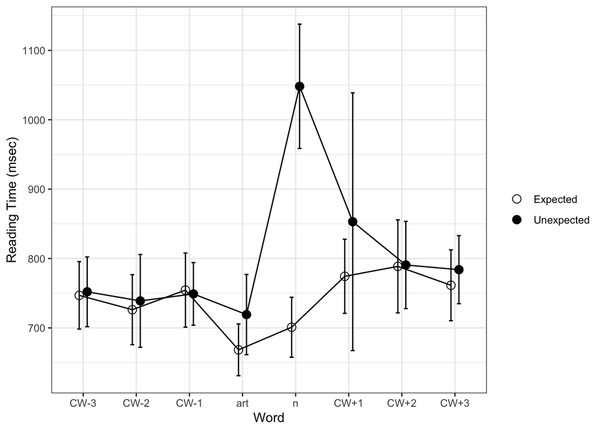

```r
# Now graph! simple enough
ggplot(rgn.rt.raw, aes(x=rgn, y=rt, group=expected, shape=expected)) +
  geom_line(stat = "identity", position=position_dodge(width=.3)) +
  geom_point(stat = "identity", position=position_dodge(width=.3), size=3) +
  geom_errorbar(aes(ymin = rt-stderr, ymax = rt+stderr), width=.15, position=position_dodge(width=.3)) +
  scale_shape_manual(name="", labels=c("Expected", "Unexpected"), values = c(21,19)) +
  xlab("Word") + ylab("Reading Time (msec)") +
  theme_bw()
```

Well it sure looks like unexpected words (especially nouns and to a lesser extent the article before the noun and the word after the noun) take longer to read than their expected counterparts!

If you’re wondering how each participant varied between the expected and unexpected parts — we’ve got you covered.

**A Fancier Graph for the Reading Time of Each Participant Individually**

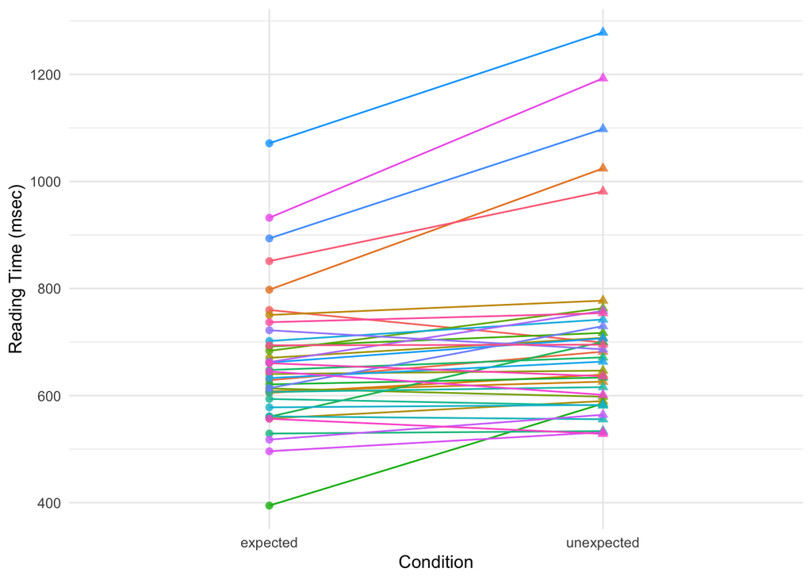

```r
df_rt |>
  filter(rgn.fix == 0) |>
  group_by(Hash, expected) |>
  summarize(RT = mean(RT, na.rm = TRUE)) |>
  ggplot(aes(x=expected, y=RT, shape = expected, group = Hash, color = Hash)) +
  geom_line() +
  geom_point(stat = "identity", alpha = .8, size = 2) +
  labs(x = "Condition", y = "Reading Time (msec)") +
  theme_minimal() +
  theme(legend.position = "none")
```

Hmmm.. it looks like there is a significant increase in reading time when the condition is unexpected to me— but it’s hard to tell without using statistics for now

But I’ll leave that fun to you!